[figure not shown]

JSS

Journal of Statistical Software

MMMMMM YYYY, Volume VV, Issue II. doi: 10.18637/jss.v000.i00

FLAME: An R Package for a Fast Large-scale

Almost Matching Exactly Approach to Causal

Inference

Chia-Rui (Jerry) Chang

Duke University

Sudeepa Roy

Duke University

Cynthia Rudin

Duke University

Alexander Volfovsky

Duke University

Abstract

The Fast Large-scale Almost Matching Exactly (FLAME) algorithm performs match-

ing of treatment and control units in the potential outcomes framework for large cate-

gorical datasets. FLAME creates matches that include as many covariates as possible,

and sequentially drops covariates that are less useful based on a match quality measure

(Match Quality – MQ). MQ combines two important elements – it considers predictive

power from machine learning on a hold out training set, and a balancing factor to ensure

that it does not remove a covariate that would ruin overlap between treatment and con-

trol groups. This work introduces the FLAME R package. We demonstrate the algorithm

and its implementation on simulated data and real world data. We also show how to

retrieve causal estimands such as average treatment eﬀect (ATE) and conditional average

treatment eﬀect (CATE) for interpretation.

Keywords: Causal inference, database systems, machine learning, matching, R.

1. Introduction

In health or social science, causal inference goes beyond simple correlations or model-based

predictions to evaluate the eﬀect of a certain treatment or intervention. For observational

data in particular, a natural and interpretable approach to estimate treatment eﬀects with

low bias is through the matching of treated and control units. Matching on covariates allows

practitioners to assess the quality of the data and analysis more easily, leading to better

2 FLAME: A Fast Large-scale Almost Matching Exactly Approach to Causal Inference

hypotheses about possible confounding, and allowing a high-quality granular justiﬁcation for

decisions based on the basis of the matched groups.

However, most current matching methods either do not match directly on covariates, or are

not high quality because they use an inﬂexible predeﬁned distance metric that causes matched

groups to be deﬁned suboptimally. These methods thus cannot be used for conditional average

treatment eﬀect (CATE) estimation, and thus may not serve some of the main interpretability

beneﬁts of matching, discussed above. For instance, propensity score matching, or other

methods that project the data onto a subspace, do not usually produce matches that are

meaningful in the original covariate space. These methods often match observations together

that have wildly diﬀerent covariates from each other. Other matching methods that use a

ﬁxed distance metric, such as nearest neighbor matching or coarsened exact matching (Iacus,

King, and Porro 2012), tend to lose accuracy in high dimensions because the distance metric

ceases to be useful; these methods also have problems with irrelevant covariates, because the

irrelevant covariates start to dominate the distance metric between observations. In other

words, because the distance metric is manually deﬁned, there is no guarantee that the quality

of matching results is any good.

The FLAME algorithm (Roy, Rudin, Volfovsky, and Wang 2017) aims to avoid these stan-

dard problems with matching discussed above. FLAME operates under the standard potential

outcomes framework with categorical covariates and binary treatment. FLAME ﬁrst uses as

many covariates as possible to create almost-exact matches, and sequentially drops covariates

that are less predictive of the outcomes. By doing this, FLAME retains the important infor-

mation needed to construct high-quality almost-exact matches. FLAME does not depend on

a ﬁxed distance measure, avoiding potential model misspeciﬁcation of the distances between

units. Particularly, the distance measure of FLAME is data-adaptive, using machine learn-

ing on a hold-out training set for determining which covariates are safe to drop in order to

retain high-quality matches. This way, the distance between observations depends on actual

covariate values – there is no latent representation (or propensity score projection) of the

covariates. Because of this, FLAME’s matches are interpretable, and allow estimation of not

only average treatment eﬀect (ATE) but also conditional average treatment eﬀect (CATE).

Because FLAME matches directly on covariates, using as many covariates as it can, we say

that its matches are “almost exact."

This work introduces the the FLAME R package. Within this package, FLAME has two

scalable implementations: one that leverage bit-vector operations for data that can ﬁt in main

memory, and a database implementation for data sets that are too large to ﬁt in memory, using

PostgreSQL (The PostgreSQL Development Team 2018) and SQLite (The SQLite Development

Team 2018). This database method can operate on millions of observations, larger than the

scale that most other matching methods are capable of. The FLAME package evaluates

the predictive quality of each covariate at each step of the algorithm using machine learning

models from Python scikit-learn package (Pedregosa, Varoquaux, Gramfort, Michel, Thirion,

Grisel, Blondel, Prettenhofer, Weiss, Dubourg, Vanderplas, Passos, Cournapeau, Brucher,

Perrot, and Duchesnay 2011) on the hold-out training set. It also considers covariate balance

when determining which covariates to drop, so that the groups do not become too imbalanced.

The following paper is organized as follows. In Section 2, we summarize the FLAME algorithm

of Roy et al. (2017). Section 3 speciﬁes the requirements for package installation. In Section

4, we introduce two datasets – one simulated (permitting for ground truth evaluation) and

the other from the U.S. Centers for Disease Control and Prevention, and demonstrate the

Journal of Statistical Software 3

application of FLAME to both datasets in Section 5. Section 6 summarizes how to retrieve

FLAME results for interpretation and granular analysis.

2. The FLAME algorithm

We present the assumptions of FLAME in section 2.1, and introduce the algorithm in section

2.2.

2.1. Assumptions

Consider a population table D = [X, Y, T ], where each row corresponds to a unit (also known

as individual or observation). X is a n x p data matrix. X

1

, X

2

, ..., X

p

are covariates. In

order for exact matches to occur, values of covariates must be either categorical or binned

continuous data. T is the treatment assignment, which takes binary values 1 (treated) and

0 (control). Y is the outcome variable. Denote Y (0) as the outcomes of units in the control

group, and Y (1) as the outcomes of units in the treatment group. We make Stable Unit

Treatment Value Assumption (SUTVA) (Rubin 1980) and strong ignorability assumption

(Rosenbaum and Rubin 1983). SUTVA speciﬁes that the outcome of one unit is not aﬀected

by the treatment assignment of any other units. Strong ignorability (also known as "ignor-

ability", "no hidden bias", or "unconfounded") assumes that (1) the treatment assignment

(T ) is conditionally independent from the potential outcomes (Y (0), Y (1)) given covariates

(X): T ⊥(Y (0), Y (1))|X, and that (2) the probability of a unit assigned to treatment group

is positive: 0 < P (T = 1|X) < 1 for all X.

2.2. The generic FLAME algorithm

Algorithm 1 demonstrates the generic FLAME algorithm. Denote D = [X, Y, T ] as the input

data, D

H

= [X

H

, Y

H

, T

H

] as the holdout training set, and covariates as J = {j

1

, j

2

, ..., j

p

}.

X is the covariate (an n × p data matrix), Y is the outcome (an n × 1 vector), and T is

the treatment indicator (an n × 1 vector). At each iteration l, FLAME ﬁnds matches with

unmatched data D

um

l

(D

um

l

⊆ D) using covariate subset J

l

(J

l

⊆ J). The results include

matched data D

m

l

and matched groups M G

l

.

At Step 1 - 2, initialize l = 0 and call function BasicExactMatch to ﬁnd exact matches in

the complete dataset D = D

0

= [X, Y, T ] using all covariates J = J

0

= {j

1

, j

2

, ..., j

p

}. Each

matched group mg ∈ M G

0

should include at least one treatment unit and one control unit.

The while loop at Step 3 is the stopping condition. If there is no more covariate to eliminate

(J

l

= ∅), the algorithm stops. We also stop FLAME if the unmatched data contains no control

unit (D

um

l,T =0

= ∅) or no treatment unit (D

um

l,T =1

= ∅). At Step 4 -5, increment l and remove

matches found in the previous iteration. In order to ﬁnd new matches, we have to reduce the

dimension of the data. Thus, we choose covariate j

∗

l

from J

l−1

to remove such that removing

it maximizes Match Quality (MQ). MQ consists of two components - Balancing Factor (BF)

and Predictive Error (PE), computed through -PE + tradeoﬀ × BF. BF assesses the proportion

of units that can be matched. PE evaluates the predictive quality of covariate subsets, built

upon machine learning models such as ridge regression and decision tree. In short, MQ is a

bias-variance tradeoﬀ between producing more matches and having better prediction.

At Step 6 - 7, we update new covariate subset (J

l

= J

l−1

\j

∗

l

) and ﬁnd new matched groups

[figure not shown]

4 FLAME: A Fast Large-scale Almost Matching Exactly Approach to Causal Inference

(MG

l

) and matched data (D

m

l

). We continue this process until any of the stopping condition

is met. Once the algorithm stops, it returns a set of covariate subset, matched groups, and

matched data as the ﬁnal output.

Algorithm 1 The generic FLAME algorithm

Input:

(i) Input data D = [X, Y, T ]

(ii) Holdout training set D

H

= [X

H

, Y

H

, T

H

]

Output:

(i) A set of covariates used for matching {J

l

}

l≥0

(ii) A set of matched groups {M G

l

}

l≥0

(iii) A set of matched data {D

m

l

}

l≥0

1: Initialize l = 0, D

um

l

= [X, Y, T ], J

l

= {j

1

, j

2

, ..., j

p

}, M G = ∅

2: (D

m

l

, M G

l

) = BasicExactMatch(D

um

l

, J

l

) (ﬁnd matches using all covariates)

3: while (i) J

l

6= ∅ and (ii) D

um

l,T =1

6= ∅ and (iii) D

um

l,T =0

6= ∅ do

4: l = l + 1

5: D

um

l

= D

um

l−1

\D

m

l−1

(remove matches)

6: J

l

= J

l−1

\j

∗

l

(new covariate subset with feature(s) removed)

7: (D

m

l

, M G

l

) = BasicExactMatch(D

um

l

, J

l

) (ﬁnd matches using new covariate subset)

8: return {J

l

, M G

l

, D

m

l

}

l≥0

(return covariate subset, matched groups, and matched data

at each iteration)

Algorithm 2 presents the BasicExactMatch function. The inputs to BasicExactMatch include

(1) unmatched data D

um

and (2) covariate subset J

l

. At Step 1, the algorithm performs

exact matching on J

l

, where it ﬁnds units with the same covariate values. Since each matched

group should contain at least one treated unit and one control unit, we remove group not

satisfying such constraint at Step 2. After matched groups are formed, we retrieve matched

data D

m

from D

um

at Step 3. Lastly, D

m

and M are returned. The implementation of

BasicExactMatch uses bit vectors and SQL query.

Algorithm 2 BasicExactMatch

Input:

(i) Unmatched data D

um

= (X, Y, T )

(ii) Covariate subset J

l

⊆ J

Output:

(i) Matched data D

m

(ii) Matched groups M G

1: M

raw

= group-by(D

um

, J

l

) (Perform exact matching on J

s

and form group for units with

the same covariate values)

2: M = prune(M

raw

) (remove groups that do not satisfy the matching constraint)

3: D

m

= Get subset of D

um

from units in M

4: return {D

m

,M}

[figure not shown]

Journal of Statistical Software 5

3. Package requirements and installation

The FLAME package can be installed from https://github.com/chiarui424/FLAME. To

install the pakcage, type the following command in R.

R> devtools::install_github("chiarui424/FLAME")

R> library(FLAME)

The package requires input data to have speciﬁc format. First, input data should be a R Data

Frame. Second, all covariates in the input data should be categorical covariates, represented

by factor data type. If there are continuous covariates, consider regrouping or binning.

Third, input data should contain (1) covariates in categorical data type, (2) outcome variable

in numeric data type, and (3) variable specifying a unit is treated or control (treated = 1,

control = 0) in factor data type. Lastly, though there are no requirements for input data

column names, the column order should follow [covariates, outcome, treated]. Table 1 is an

example of input data with n units and p covariates. Holdout training set should also follow

the same format.

x

1

x

2

... x

p−1

x

p

outcome treated

R data type factor factor factor factor factor numeric factor

unit 1 0 1 ... 1 2 3.8 1

unit 2 1 0 ... 1 0 1.36 0

unit 3 0 1 ... 0 1 -7.25 0

... ... ... ... ... ... ... ...

unit n 0 1 ... 1 0 20 1

Table 1: Input data example

Since FLAME relies on python and database management systems, other requirements to run

the package include:

• FLAME requires installation of python (Python Software Foundation 2018), speciﬁcally

with at least python 2.7 version. If your computer system does not have python 2.7,

install from https://www.python.org/downloads/.

• For database systems implementation, FLAME package provides two versions - SQLite

and PostgreSQL. PostgreSQL requires installation of external database system but it is

faster. SQLite does not require external database system but is slower. If your com-

puter does not have PostgreSQL installed, install it from https://www.postgresql.

org/download/. For connecting and setup of PostgreSQL server, please refer to the tuto-

rial at http://www.postgresqltutorial.com/connect-to-postgresql-database/.

• It is required to name the connection as db once connected to the database. We will

demonstrate how to implement it in section 5.

Table 2 list all functions in FLAME.

4. Data

[figure not shown]

6 FLAME: A Fast Large-scale Almost Matching Exactly Approach to Causal Inference

Function Description

ATE Compute average treatment eﬀect (ATE) of all mathed groups

AVG_EFFECT Compute the treatment eﬀects of matched group(s)

CATE Get the size and CATE of matched group(s)

CATE_plot Summarize CATEs of all matched groups by Boxplot

Data_Generation Generate simulated data

FLAME_bit Bit vectors implementation

FLAME_PostgreSQL PostgreSQL database implementation

FLAME_SQLite SQLite database implementation

MATCH Get units in matched group(s) given certain covariate combination

summary_plot Visualize matching process

Table 2: Functions in the FLAME package

We introduce two datasets for package demonstration, one from simulation and the other from

Centers for Disease Control and Prevention. For simulated data, function Data_Generation

generates the data with speciﬁc characteristics and known treatment eﬀects.

y

i

=

n

X

j=1

α

j

x

j

+ T

i

n

X

j=1

β

j

x

j

+ T

i

· U

X

j=1..5,γ=1...5,γ>j

x

j

x

γ

(1)

T

i

∈ {0, 1} indicates whether a unit i is treated or control, and U represents the coeﬃcient

of non-linear term. Here, x

j

∼ Bernoulli(0.5), α

j

∼ N (10s, 1) with s ∼ U niform{−1, 1},

and β

j

∼ N (1.5, 0.15). For package demonstration, the simulated data contains 5,000 treated

units and 5,000 control units with U = 5. In addition, there are 10 important covariates and

5 unimportant covariates. Important covariates are those used to generate the true outcome

y

i

, whereas unimportant covariates are random samples from Bernoulli(0.5). For the simu-

lated data below, x

1

, x

2

, ..., x

10

are important covariates and x

11

, x

12

, ..., x

15

are unimportant

covariates. We assume holdout training set to be the same as simulated data. The following

code is used to generate simulated data.

R> set.seed(1234) # set seed for reproducibility

R> sim_data = FLAME::Data_Generation(num_control = 5000, num_treated = 5000,

+ num_cov_dense = 10, num_cov_unimportant = 5, U = 5)

R> sim_holdout = sim_data

R> head(sim_data)

x1 x2 x3 x4 x5 x6 x7 x8 x9 x10 x11 x12 x13 x14 x15 outcome treated

1 0 0 0 0 0 0 1 0 0 1 1 1 0 0 1 -11.541 0

2 1 0 0 0 1 0 1 1 0 1 1 0 0 1 1 0.547 0

3 1 1 1 0 1 0 0 0 0 1 1 1 0 0 1 -2.263 0

4 1 1 1 0 1 0 0 1 0 0 1 1 0 1 1 6.491 0

5 1 0 0 0 1 1 1 1 0 1 1 0 1 1 0 -7.093 0

6 1 1 0 0 1 0 1 0 1 0 1 0 1 0 0 0.454 0

For real world data, we use U.S. 2010 natality dataset (Centers for Disease Control and

Prevention 2010). We randomly sample 10 percent of the data, where there are 219,041

Journal of Statistical Software 7

units with 86 covariates. Each unit is a pregnant mother. Covariates are mother’s health

conditions during pregnancy. The outcome indicates whether the infant has abnormal health

conditions after birth. Abnormal conditions include assisted aentilation, admission to NICU,

surfactant therapy received, antibiotics received for suspected neonatal sepsis and seizures or

serious neurologic dy sfunction. Infant with abnormal conditions has outcome ’1’, while infant

with normal conditions has outcome ’0’. Since we would like to evaluate the eﬀect of smoking

during pregnancy on infant abnormal health conditions, mothers who smoke cigarettes during

pregnancy are assigned to be treated. There are 20,551 treated units and 198,490 control units.

5. Running the FLAME package

We demonstrate running the package on simulated data in section 5.1 and natality data

in section 5.2. The main functions for running FLAME are FLAME_bit, FLAME_SQLite and

FLAME_PostgreSQL. The inputs for all three functions include input data and holdout training

set, where the format of the data should follow the requirements in section 3.

Note that there are other optional inputs related to Match Quality. If these optional inputs

are not speciﬁed, the default is set to Ridge Regression with tradeoﬀ parameter of 0.1. We

focus on running major functions in this section, so Match Quality is set to default. The

details of specifying Match Quality parameters is introduced in section 7.

5.1. Application to simulated data

FLAME_bit: We apply FLAME_bit function to the simulated data and save the result as

result_bit. Note that if we want to compute the variance of each matched group, we can

specify optioanl argument compute_var = TRUE. The variance of each matched group is the

sum of the variance of the treated units and the variance of the control units, so each matched

group should contain at least 2 treated units and 2 control units. Therefore, it is expected

that less matched units will be found in earlier iteration if compute_var = TRUE.

R> result_bit <- FLAME_bit(data = sim_data, holdout = sim_holdout)

FLAME_PostgreSQL: Database system implementation with PostgreSQL version is developed

with package RPostgreSQL (Conway, Eddelbuettel, Nishiyama, Prayaga, and Tiﬃn 2017). It

requires additional input db, name of the connection. Note that it is required to name the

connection as db as mentioned in section 3. The following code connects to PostgreSQL in R,

runs FLAME_PostgreSQL function, saves the result as result_PostgreSQL, and disconnects

db once done.

R> drv = dbDriver('PostgreSQL')

R> db = dbConnect(drv, user="postgres", dbname="FLAME", host='localhost',

+ port=5432, password = 'new_password')

R> result_PostgreSQL = FLAME_PostgreSQL(db = db, data = sim_data, holdout = sim_holdout)

R> dbDisconnect(db)

FLAME_SQLite: Database system implementation with SQLite version is developed with pack-

age RSQLite (MÃĳller, Wickham, James, and Falcon 2018). Similar to FLAME_PostgreSQL,

8 FLAME: A Fast Large-scale Almost Matching Exactly Approach to Causal Inference

FLAME_SQLite also requires additional input db, where the connection must be named as

db. The following code connects to a temporary database in R, runs FLAME_SQLite function,

saves the result as result_SQLite, and disconnects db once done. Note that the name of

the temporary database can be arbitrary. Here, we name it as "tempdb".

R> db = dbConnect(SQLite(),"tempdb")

R> result_SQLite = FLAME_SQLite(db = db, data = sim_data, holdout = sim_holdout)

R> dbDisconnect(db)

FLAME returns the same outputs regardless of bit vector or database implementations. The

outputs include:

1. covariate_list: set of covariates FLAME performs matching at each iteration ({J

l

}

l≥0

in algorithm 1)

2. matched_group: set of matched groups ({M G

l

}

l≥0

in algorithm 1)

3. match_quality: Match Quality at each iteration

4. matched_data: The original data with additional column matched, indicating the

number of covariates FLAME performs matching. For example, if a unit is matched

with 5 covariates, then the matched column of this unit is 5. If a unit is never matched,

then matched will be 0.

We compare the results of all three implementations, which yield the same results.

• We apply summary function to examine average treatment eﬀect and number of matches.

R> summary(result_bit) #bit vectors

[1] "Number of units matched = 9950"

[1] "Average treatment effect = 19.6186217266224"

R> summary(result_SQLite) #PostgreSQL

[1] "Number of units matched = 9950"

[1] "Average treatment effect = 19.6186217266224"

R> summary(result_PostgreSQL) #SQLite

[1] "Number of units matched = 9950"

[1] "Average treatment effect = 19.6186217266224"

• The covariates FLAME performs matching at the 8

th

iteration.

R> result_bit$covariate_list[[8]] #bit vectors

[1] "x1" "x2" "x3" "x4" "x5" "x6" "x7" "x10"

Journal of Statistical Software 9

R> result_PostgreSQL$covariate_list[[8]] #PostgreSQL

[1] "x1" "x2" "x3" "x4" "x5" "x6" "x7" "x10"

R> result_SQLite$covariate_list[[8]] #SQLite

[1] "x1" "x2" "x3" "x4" "x5" "x6" "x7" "x10"

• All matched groups at the 8

th

iteration. Column eﬀect is the conditional average

treatment eﬀect (CATE) and column size is the number of units in each matched

group.

R> head(result_bit$matched_group[[8]]) #bit vectors

x1 x2 x3 x4 x5 x6 x7 x10 effect size

1 0 0 0 0 0 1 0 0 -0.2217 9

2 0 0 0 1 0 0 1 0 1.6640 11

3 0 0 0 0 1 0 1 0 1.8027 8

4 0 1 0 0 0 0 0 0 1.8442 10

5 0 0 0 0 0 0 1 1 3.1416 6

6 0 0 0 0 0 0 1 0 4.4867 8

R> head(result_PostgreSQL$matched_group[[8]]) #PostgreSQL

x1 x2 x3 x4 x5 x6 x7 x10 effect size

1 0 0 0 0 0 1 0 0 -0.2217 9

2 0 0 0 1 0 0 1 0 1.6640 11

3 0 0 0 0 1 0 1 0 1.8027 8

4 0 1 0 0 0 0 0 0 1.8442 10

5 0 0 0 0 0 0 1 1 3.1416 6

6 0 0 0 0 0 0 1 0 4.4867 8

R> head(result_SQLite$matched_group[[8]]) #SQLite

x1 x2 x3 x4 x5 x6 x7 x10 effect size

1 0 0 0 0 0 1 0 0 -0.2217 9

2 0 0 0 1 0 0 1 0 1.6640 11

3 0 0 0 0 1 0 1 0 1.8027 8

4 0 1 0 0 0 0 0 0 1.8442 10

5 0 0 0 0 0 0 1 1 3.1416 6

6 0 0 0 0 0 0 1 0 4.4867 8

5.2. Package illustration with U.S. Natality Data

In this section, we demonstrate how to apply FLAME to 2010 U.S. Natality Data. To recap,

the data aims to study the eﬀect of smoking during pregnancy on the health outcome of

infants. Each unit is a pregnant mother. Covariates indicate mothers’ health condition

10 FLAME: A Fast Large-scale Almost Matching Exactly Approach to Causal Inference

during pregnancy. Treatment group are mothers who smoke during pregnancy. Outcome

indicates whether the health conditions of infant are normal (’0’) or abnormal (’1’). There

are 20,551 treated units, 198,490 control units, and 86 covariates. Holdout training set is

the same as input data. Given the scale of the data, we apply FLAME_PostgreSQL for faster

implementation.

First, we connect to the database in R and name the connection as db. Second, we run

FLAME_PostgreSQL. Here, ridge regression with tradeoﬀ parameter of 0.1 is used to compute

Match Quality (default). Third, we disconnect db once the matching is done.

R> drv <- dbDriver('PostgreSQL')

R> db<- dbConnect(drv, dbname="FLAME", host='localhost',

+ port=5432, user="postgres", password = 'new_password')

R> result_natality <- FLAME_PostgreSQL(db = db, data, holdout)

R> dbDisconnect(db)

The average treatment eﬀect (ATE) of the population is approximately 0.04834. This indiates

smoking during pregnancy increases the chance of abnormal pregnancy outcomes by 4.8 %.

R> summary(result_natality)

[1] "Number of units matched = 153903"

[1] "Average treatment effect = 0.048349247835241"

6. Access detailed information for interpretation

After running FLAME, we can access detailed information such as conditional average treat-

ment eﬀect (CATE) of each matched group and average treatment eﬀect (ATE) of the matched

samples with functions CATE, MATCH, AVG_EFFECT, and CATE_plot. Table 3 summarizes the

input parameters of each function.

Here, we demonstrate how to retrieve conditional average treatment eﬀect (CATE) using

results from section 5.

1. Let’s look at the iteration when the FLAME algorithm performs matching with 8 co-

variates. These 8 covariates are:

[1] "x1" "x2" "x3" "x4" "x5" "x6" "x7" "x10"

If we want to access all matched groups and each group’s CATE at this iteration, apply

CATE function by specifying parameter FLAME_object and num_covs.

R> head(CATE(FLAME_object = result_bit, num_covs = 8))

x1 x2 x3 x4 x5 x6 x7 x10 effect size

1 0 0 0 0 0 1 0 0 -0.2217 9

2 0 0 0 1 0 0 1 0 1.6640 11

[figure not shown]

Journal of Statistical Software 11

function parameter description

CATE

FLAME_object object returned by applying the FLAME matching algorithm

(result_bit, result_PostgreSQL, and result_SQLite)

num_covs number of covariates FLAME performs matching with

cov_name a vector of covariate names

cov_val a vector of covariate values, where the value position should match

cov_name position (each element has to be character data type)

MATCH

FLAME_object object returned by applying the FLAME matching algorithm

(result_bit, result_PostgreSQL, and result_SQLite)

cov_name a vector of covariate names

cov_val a vector of covariate values, where the value position should match

cov_name position (each element has to be character data type)

AVG_EFFECT CATE_object object returned by applying CATE function

CATE_plot CATE_object object returned by applying CATE function

Table 3: Input parameters

3 0 0 0 0 1 0 1 0 1.8027 8

4 0 1 0 0 0 0 0 0 1.8442 10

5 0 0 0 0 0 0 1 1 3.1416 6

6 0 0 0 0 0 0 1 0 4.4867 8

2. Let’s look at one of the matched groups. This matched group has the following covariate

combination.

x1 x2 x3 x4 x5 x6 x7 x10

"0" "0" "0" "0" "0" "1" "0" "0"

If we want to see the CATE and matched size of this covariate combination, we can

apply CATE function by specifying all parameters.

R> cov_name #covariate names

[1] "x1" "x2" "x3" "x4" "x5" "x6" "x7" "x10"

R> cov_val #covariate values in character R data type

[1] "0" "0" "0" "0" "0" "1" "0" "0"

R> CATE(FLAME_object = result_bit, num_covs = 8,

+ cov_name = cov_name, cov_val = cov_val)

x1 x2 x3 x4 x5 x6 x7 x10 effect size

1 0 0 0 0 0 1 0 0 -0.2217 9

3. If we want to know which observations/units produce this covariate combination, we

can apply MATCH function by specifying all parameters.

12 FLAME: A Fast Large-scale Almost Matching Exactly Approach to Causal Inference

R> MATCH(FLAME_object = result_bit, cov_name = cov_name, cov_val = cov_val)

x1 x2 x3 x4 x5 x6 x7 x8 x9 x10 x11 x12 x13 x14 x15 outcome treated

1 0 0 0 0 0 1 0 1 0 0 0 0 0 0 1 -7.307 0

2 0 0 0 0 0 1 0 0 0 0 1 1 0 1 1 -7.640 0

3 0 0 0 0 0 1 0 0 0 0 1 0 1 1 1 -7.640 0

4 0 0 0 0 0 1 0 1 0 0 0 1 1 1 0 -7.307 0

5 0 0 0 0 0 1 0 0 1 0 1 0 1 1 1 -7.695 1

6 0 0 0 0 0 1 0 0 1 0 1 0 0 0 0 -7.695 1

7 0 0 0 0 0 1 0 0 1 0 1 1 1 0 0 -7.695 1

8 0 0 0 0 0 1 0 0 1 0 0 1 0 0 0 -7.695 1

9 0 0 0 0 0 1 0 0 1 0 0 0 0 0 1 -7.695 1

index

1 8741

2 8793

3 8803

4 8804

5 8929

6 8934

7 8954

8 8998

9 9080

4. Assume we want to see all matched groups with the covariate combination x1 = 1,

x3 = 0, x5 = 1, x7 = 0, x9 = 1. Particularly, even when the FLAME algorithm

performs matching with more than 5 covariates, we can still output all possible matches

as long as it contains the speciﬁed covariate combination. We apply CATE function by

specifying parameters FLAME_object, cov_name, and cov_val.

R> CATE_object <- CATE(FLAME_object = result_bit,

+ cov_name = c("x1", "x3", "x5", "x7", "x9"),

+ cov_val = c("1", "0", "1", "0", "1"))

[[1]]

x1 x2 x3 x4 x5 x6 x7 x8 x9 x10 x11 x12 x13 x14 x15 effect size

168 1 0 0 0 1 0 0 0 1 0 0 1 1 0 1 9.534 2

231 1 0 0 0 1 0 0 1 1 0 1 0 0 0 0 11.055 2

232 1 0 0 0 1 0 0 1 1 0 1 1 0 1 0 11.055 2

233 1 0 0 0 1 0 0 1 1 0 0 0 1 1 0 11.055 2

234 1 0 0 0 1 0 0 1 1 0 1 1 0 1 1 11.055 2

289 1 0 0 0 1 1 0 0 1 1 0 1 0 0 0 12.350 2

[[2]]

x1 x2 x3 x4 x5 x6 x7 x8 x9 x10 x11 x13 x14 x15 effect size

137 1 0 0 0 1 0 0 0 1 1 1 0 1 0 10.90 3

142 1 0 0 0 1 1 0 0 1 0 1 0 0 1 10.98 2

146 1 0 0 0 1 0 0 1 1 0 0 0 0 0 11.05 2

Journal of Statistical Software 13

193 1 0 0 0 1 1 0 1 1 0 1 1 1 1 12.50 2

281 1 0 0 1 1 0 0 0 1 1 1 0 1 1 22.20 2

297 1 0 0 1 1 0 0 1 1 0 1 1 0 1 22.35 2

[[3]]

x1 x2 x3 x4 x5 x6 x7 x8 x9 x10 x11 x13 x14 effect size

124 1 0 0 0 1 0 0 0 1 0 1 1 1 9.534 2

181 1 0 0 0 1 1 0 0 1 0 1 1 1 10.981 2

183 1 0 0 0 1 0 0 1 1 0 1 1 0 11.055 2

184 1 0 0 0 1 0 0 1 1 0 0 0 1 11.055 2

185 1 0 0 0 1 0 0 1 1 0 1 1 1 11.055 3

236 1 0 0 0 1 0 0 1 1 1 1 0 0 12.424 2

[[4]]

x1 x2 x3 x4 x5 x6 x7 x8 x9 x10 x11 x14 effect size

216 1 0 0 0 1 0 0 0 1 1 1 0 10.90 2

278 1 0 0 0 1 1 0 0 1 1 0 1 12.35 3

291 1 0 0 0 1 1 0 1 1 0 0 0 12.50 5

323 1 0 0 0 1 1 0 1 1 1 1 0 13.87 2

324 1 0 0 0 1 1 0 1 1 1 0 1 13.87 2

431 1 0 0 1 1 1 0 0 1 0 1 1 22.27 2

[[5]]

x1 x2 x3 x4 x5 x6 x7 x8 x9 x10 x11 effect size

158 1 0 0 0 1 0 0 0 1 1 0 10.90 3

168 1 0 0 0 1 1 0 0 1 0 1 10.98 2

282 1 0 0 1 1 1 0 0 1 0 0 22.27 3

294 1 1 0 0 1 0 0 0 1 1 0 22.39 2

336 1 0 0 1 1 0 0 1 1 1 0 23.72 3

346 1 0 0 1 1 1 0 1 1 0 1 23.80 3

[[6]]

x1 x2 x3 x4 x5 x6 x7 x8 x9 x10 effect size

123 1 1 0 0 1 0 0 0 1 0 21.03 5

139 1 0 0 1 1 0 0 1 1 0 22.35 6

155 1 0 0 1 1 1 0 1 1 1 25.16 4

176 1 1 0 1 1 0 0 0 1 1 38.69 2

177 1 1 0 1 1 1 0 0 1 0 38.77 11

179 1 1 0 1 1 0 0 1 1 0 38.84 5

[[7]]

x1 x2 x3 x4 x5 x6 x7 x9 x10 effect size

33 1 0 0 0 1 0 0 1 0 11.39 6

48 1 0 0 0 1 1 0 1 0 12.84 7

56 1 0 0 0 1 1 0 1 1 14.20 5

73 1 1 0 0 1 0 0 1 1 22.06 6

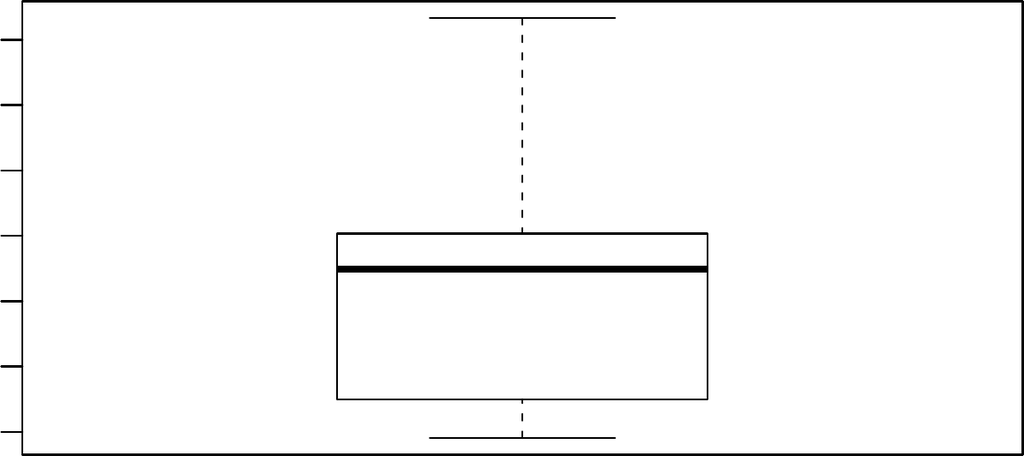

14 FLAME: A Fast Large-scale Almost Matching Exactly Approach to Causal Inference

5. To compute estimated treatment eﬀects of matched groups, we apply AVG_EFFECT func-

tion. Note that estimated treatment eﬀect is the weighted average of CATEs, with

weight being the number of units in each matched group. In addition, we can visualize

the distribution of all CATEs in boxplot by applying CATE_plot function.

R> CATE_plot(CATE_object)

R> AVG_EFFECT(CATE_object)

[1] 23.49

10 20 30 40

CATE summary with 272 matched units

CATE

To get the summary of average treatment eﬀect (ATE), we can apply function ATE and

summary_plot. The input parameter of both functions is the object returned by apply-

ing the FLAME algorithm. In our example, it is result_bit, result_PostgreSQL, or

result_SQLite. ATE computes average treatment eﬀect for each given sub-population by

a weighted average of the estimated treatment eﬀects in each matched group. The weight is

the number of units in each matched group.

R> FLAME::ATE(result_bit)

[1] 19.62

We can also apply summary_plot function to visualize the process of matching as the algo-

rithm drops covariate iteratively. The x-axis is the covariate dropped at each iteration. The

y-axis on the left is the number of units matched, and the y-axis on the right is the estimated

treatment eﬀects. Note that since all covariates are used for matching in the beginning, no

covariate is dropped and is represented by NA in the covariate dropped axis.

R> FLAME::summary_plot(result_bit)

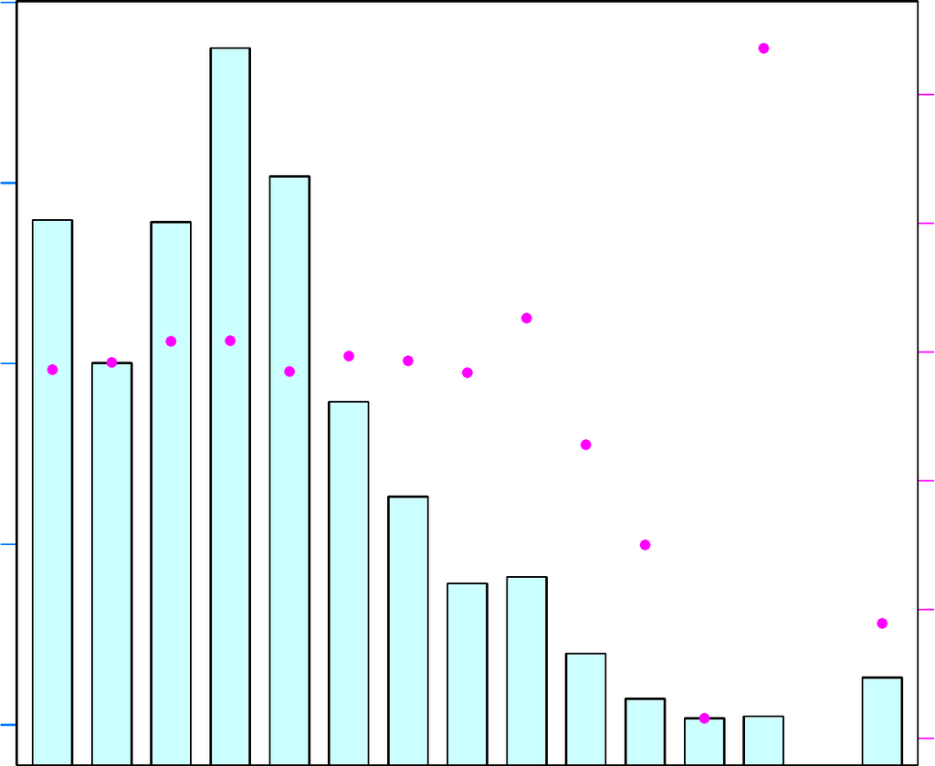

Journal of Statistical Software 15

Summary Plot

covariate dropped

NA x12 x15 x13 x14 x11 x8 x9 x7 x2 x6 x3 x10 x1 x5

0

500

1000

1500

5

10

15

20

25

30

estimated treatment effects

number of units matched

7. Specifying Match Quality

One of the key steps for FLAME is that it removes covariate iteratively according to Match

users who prefer covariate subset that produces more matched units should choose higher

tradeoﬀ parameter, whereas users who prefer covariate subset that produces better predictive

accuracy should choose lower tradeoﬀ parameter. The default tradeoﬀ parameter is set to

0.1. Second, users can choose appropriate statistical model to compute predictive error. The

FLAME package currently provides four models; respectively they are Linear Regression,

Ridge Regression, LASSO, and Decision Tree. The default model is set to ridge regression

with L2 regularization parameter of 0.1. If users would like to use models not supported by

the package, they can provide an input R function that computes predictive error. Table 4

summarizes the Match Quality parameters.

We demonstrate how to specify predictive models based on bit vectors implementation.

1. Linear Regression - specify this operation as model = "Linear"

R> FLAME_bit(data = data, holdout = holdout, model = "Linear")

2. Ridge Regression with L2 regularization parameter of 0.1 - specify this operation as

model = "Ridge", ridge_reg = 0.1

R> FLAME_bit(data = data, holdout = holdout, model = "Ridge", ridge_reg = 0.1)

[figure not shown]

16 FLAME: A Fast Large-scale Almost Matching Exactly Approach to Causal Inference

parameter description

tradeoff tradeoﬀ parameter to compute Match Quality. Default = 0.1.

PE_function statistical model speciﬁed in R function to compute predivtive

error

model options include “Linear” (linear regression), “Ridge” (ridge re-

gression), “Lasso” Lasso, or “DecisionTree” (classiﬁcation and re-

gression tree). Default is set to “Ridge”.

ridge_reg L2 regularization parameter if model = "Ridge". Default = 0.1.

lasso_reg L1 regularization parameter if model = "Lasso". Default = 0.1.

tree_depth maximum depth of decision tree if model = "DecisionTree".

Table 4: Optional parameters related to Match Quality

3. Lasso with L1 regularization regularization parameter of 0.1 - specify this operation as

model = "Lasso", lasso_reg = 0.1

R> FLAME_bit(data = data, holdout = holdout, model = "Lasso", lasso_reg = 0.1)

4. Decision Tree with maximum depth of 8 - specify this operation as model = "DecisionTree",

tree_depth = 8

R> FLAME_bit(data = data, holdout = holdout, model = "DecisionTree", tree_depth = 8)

If users would like to use the model not supported by the package, users can specify their own

model with parameter PE_function. The inputs to PE_function consist of four parameters,

summarized in table 5. Predictive error is the sum of mean squared error (MSE) for treated

group and mean squared error (MSE) for control group. outcome_treated and covs_treated

is used to compute the MSE for treated group, and outcome_control and covs_control is

used to compute the MSE for control group.

outcome_treated outcomes of treated units in vector data type

outcome_control outcomes for control units in vector data type

covs_treated covariate values for treated units in matrix data type

covs_control covariate values for control units in matrix data type

Table 5: parameters of PE function

Here, we write a R function that computes predictive error based on support vector machine

(SVM). The name of the function is SVM_PE, which is based on SVM model in e1071 package

(Meyer, Dimitriadou, Hornik, Weingessel, and Leisch 2017).

R> SVM_PE <- function(outcome_treated, outcome_control, covs_treated, covs_control) {

+

+ library(e1071) #load e1071 library

+

+ # MSE for treated group

+ model_svm <- svm(outcome_treated ~ covs_treated) # fit the data to SVM model

Journal of Statistical Software 17

+ pred_treated <- predict(model_svm, covs_treated) #get fitted values

+ MSE_treated <- sum((outcome_treated - pred_treated)^2)/length(outcome_treated)

+

+ # MSE for control

+ model_svm <- svm(outcome_control ~ covs_control) # fit the data to SVM model

+ pred_control <- predict(model_svm, covs_control) #get predicted values

+ MSE_control <- sum((outcome_control - pred_control)^2)/length(outcome_control)

+

+ return(MSE_treated + MSE_control)

+ }

We then specify PE_function = SVM_PE and apply it to any of the FLAME implementation.

R> FLAME_bit(data = data, holdout = holdout, PE_function = SVM_PE)

Acknowledgments

We thank Tianyu Wang for providing Python code and technical assistance.

References

Centers for Disease Control and Prevention (2010). “Birth Data.” Data retrieved from Na-

tional Vital Statistics System, https://www.cdc.gov/nchs/nvss/births.htm.

Conway J, Eddelbuettel D, Nishiyama T, Prayaga SK, Tiﬃn N (2017). RPostgreSQL: R

Interface to the PostgreSQL Database System. R package version 0.6-2, URL https://

cran.r-project.org/web/packages/RPostgreSQL/index.html.

Iacus SM, King G, Porro G (2012). “Causal inference without balance checking: Coarsened

exact matching.” Political analysis, 20(1), 1–24.

Meyer D, Dimitriadou E, Hornik K, Weingessel A, Leisch F (2017). e1071: Misc Functions

of the Department of Stat istics, Probability Theory Group (Formerly: E1071), TU Wien.

R package version 1.6-8, URL https://CRAN.R-project.org/package=e1071.

R package version 2.1-1, URL https://cran.r-project.org/web/packages/RSQLite/

index.html.

Pedregosa F, Varoquaux G, Gramfort A, Michel V, Thirion B, Grisel O, Blondel M, Pretten-

hofer P, Weiss R, Dubourg V, Vanderplas J, Passos A, Cournapeau D, Brucher M, Perrot

M, Duchesnay E (2011). “Scikit-learn: Machine Learning in Python.” Journal of Machine

Learning Research, 12, 2825–2830.

Python Software Foundation (2018). Python Software, Version 2.7. URL http://www.

python.org.

[figure not shown]

18 FLAME: A Fast Large-scale Almost Matching Exactly Approach to Causal Inference

Rosenbaum PR, Rubin DB (1983). “The central role of the propensity score in observational

studies for causal eﬀects.” Biometrika, 70(1), 41–55.

Roy S, Rudin C, Volfovsky A, Wang T (2017). “FLAME: A Fast Large-scale Almost Matching

Exactly Approach to Causal Inference.” arXiv preprint arXiv:1707.06315.

Rubin DB (1980). “Bias reduction using Mahalanobis-metric matching.” Biometrics, pp.

293–298.

The PostgreSQL Development Team (2018). PostgreSQL. URL https://www.postgresql.

org.

The SQLite Development Team (2018). SQLite. URL https://www.sqlite.org.

Aﬃliation:

Chia-Rui (Jerry) Chang

Department of Statistical Science

Duke University

Durham, North Carolina

E-mail: chiarui424@gmail.com

Sudeepa Roy

Department of Computer Science

Duke University

Durham, North Carolina

E-mail: sudeepa@cs.duke.edu

Cynthia Rudin

Department of Computer Science and Electrical and Computer Engineering

Duke University

Durham, North Carolina

E-mail: cynthia@cs.duke.edu

Alexander Volfovsky

Department of Statistical Science

Duke University

Durham, North Carolina

E-mail: alexander.volfovsky@duke.edu

Journal of Statistical Software http://www.jstatsoft.org/

published by the Foundation for Open Access Statistics http://www.foastat.org/

MMMMMM YYYY, Volume VV, Issue II Submitted: yyyy-mm-dd

doi:10.18637/jss.v000.i00 Accepted: yyyy-mm-dd